# APPAREL PRICE PREDICTION DATASET: BRAND, CATEGORY, AND MATERIAL ATTRIBUTES FOR MACHINE LEARNING MODELS

```python
import pandas as pd
```

```python
df=pd.read_csv(r"clothes images/clothes_price_prediction_data.csv")
```

## 1. How do brand affiliations statistically influence apparel pricing across categories?

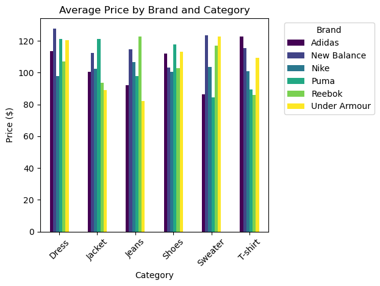

```python
import pandas as pd
import matplotlib.pyplot as plt

# Load data
df = pd.read_csv(r"clothes images/clothes_price_prediction_data.csv")

# Group by Brand and Category, calculate mean price
grouped = df.groupby(['Brand', 'Category'])['Price'].mean().reset_index()
pivot_table = grouped.pivot(index='Category', columns='Brand', values='Price')

# Plot
plt.figure(figsize=(12, 6))
pivot_table.plot(kind='bar', stacked=False, colormap='viridis')
plt.title('Average Price by Brand and Category')
plt.xlabel('Category')
plt.ylabel('Price ($)')
plt.xticks(rotation=45)
plt.legend(title='Brand', bbox_to_anchor=(1.05, 1))
plt.tight_layout()
plt.savefig("Average Price by Brand and Category.png")
plt.show()
```

## 2. Which material-category combinations yield the highest price premiums?

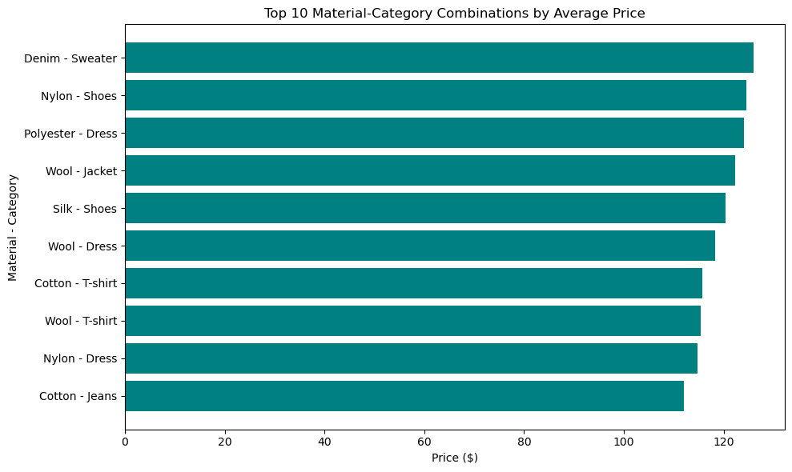

```python
# Calculate mean price for material-category pairs
material_category = df.groupby(['Material', 'Category'])['Price'].mean().reset_index()
material_category_sorted = material_category.sort_values('Price', ascending=False).head(10)

# Plot
plt.figure(figsize=(10, 6))
plt.barh(material_category_sorted['Material'] + " - " + material_category_sorted['Category'],
         material_category_sorted['Price'], color='teal')
plt.title('Top 10 Material-Category Combinations by Average Price')
plt.xlabel('Price ($)')
plt.ylabel('Material - Category')
plt.gca().invert_yaxis()
plt.tight_layout()
plt.savefig("Top 10 Material-Category Combinations by Average Price.png")
plt.show()
```

## 3. Do garment sizes (e.g., XS vs. XXL) correlate with price variations?

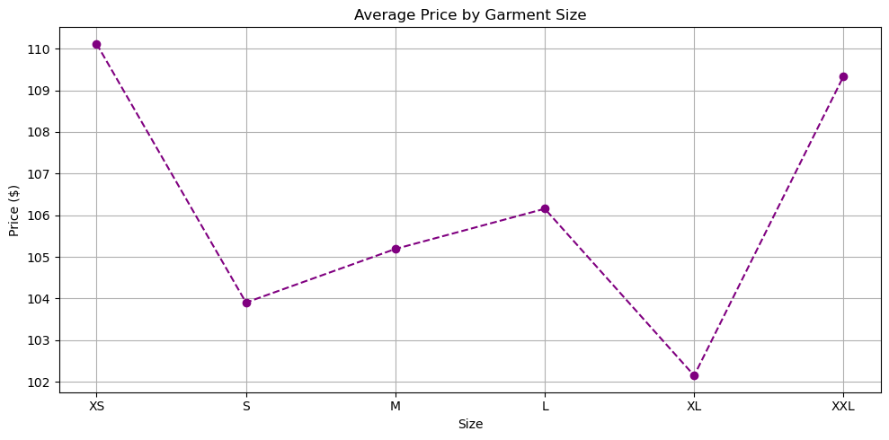

```python
# Group by Size and calculate mean price
size_price = df.groupby('Size')['Price'].mean().reindex(['XS', 'S', 'M', 'L', 'XL', 'XXL'])

# Plot line chart
plt.figure(figsize=(10, 5))
plt.plot(size_price.index, size_price.values, marker='o', linestyle='--', color='purple')
plt.title('Average Price by Garment Size')
plt.xlabel('Size')
plt.ylabel('Price ($)')
plt.grid(True)
plt.tight_layout()
plt.savefig("Average Price by Garment Size.png")
plt.show()
```

## 4. How does color popularity interact with pricing strategies in high-end vs. budget segments?

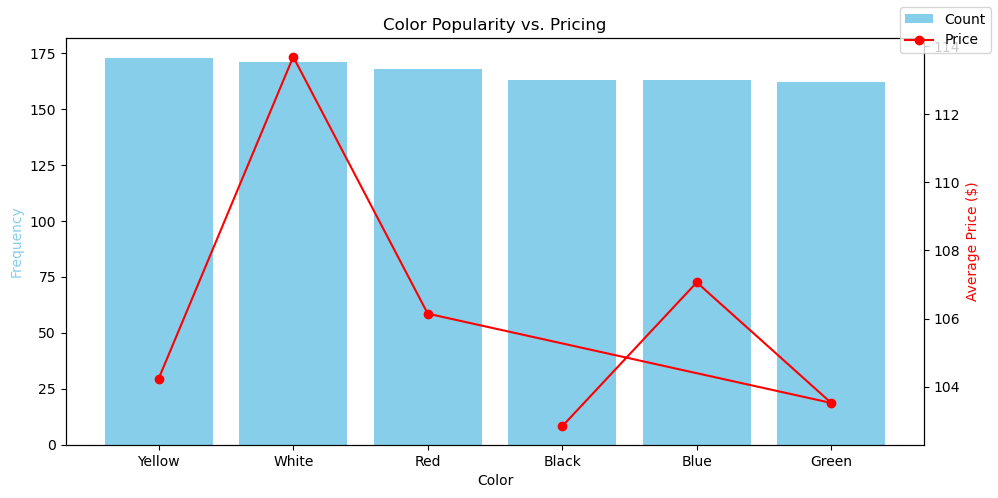

```python
# Calculate color frequency and average price
color_counts = df['Color'].value_counts()
color_prices = df.groupby('Color')['Price'].mean()

# Plot dual axes
fig, ax1 = plt.subplots(figsize=(10, 5))
ax1.bar(color_counts.index, color_counts.values, color='skyblue', label='Count')
ax2 = ax1.twinx()
ax2.plot(color_prices.index, color_prices.values, color='red', marker='o', label='Price')
ax1.set_xlabel('Color')
ax1.set_ylabel('Frequency', color='skyblue')
ax2.set_ylabel('Average Price ($)', color='red')
plt.title('Color Popularity vs. Pricing')
fig.legend(loc='upper right')
plt.tight_layout()
plt.savefig("Color Popularity vs. Pricing.png")
plt.show()
```

## 5. What percentage of price variability is explained by brand alone vs. material or size?

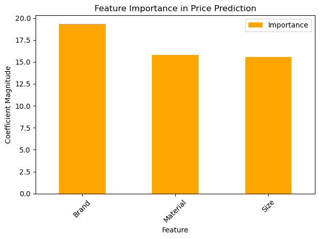

```python
from sklearn.linear_model import LinearRegression
from sklearn.preprocessing import OneHotEncoder
import numpy as np

# Encode categorical features
encoder = OneHotEncoder()
X = encoder.fit_transform(df[['Brand', 'Material', 'Size']])
y = df['Price']

# Fit regression model
model = LinearRegression()
model.fit(X, y)
r_squared = model.score(X, y)

# Feature importance (coefficient magnitudes)
importance = np.abs(model.coef_)
features = encoder.get_feature_names_out()
df_importance = pd.DataFrame({'Feature': features, 'Importance': importance})
df_importance = df_importance.groupby(df_importance['Feature'].str.split('_').str[0]).sum()

# Plot
plt.figure(figsize=(8, 5))
df_importance.plot(kind='bar', color='orange')
plt.title('Feature Importance in Price Prediction')
plt.xlabel('Feature')
plt.ylabel('Coefficient Magnitude')
plt.xticks(rotation=45)
plt.tight_layout()
plt.savefig("Feature Importance in Price Prediction.png")
plt.show()
```

## 6. Which brands dominate specific categories (e.g., Nike in Shoes) through aggressive pricing?

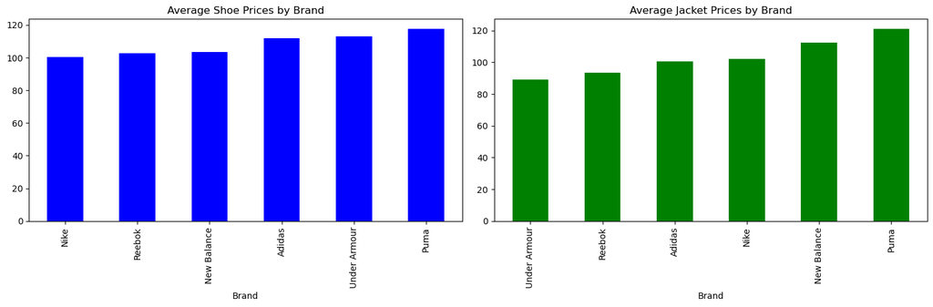

```python
# Filter data for Shoes and Jackets
shoes = df[df['Category'] == 'Shoes']
jackets = df[df['Category'] == 'Jacket']

# Plot
fig, axes = plt.subplots(1, 2, figsize=(15, 5))
shoes.groupby('Brand')['Price'].mean().sort_values().plot(kind='bar', ax=axes[0], color='blue', title='Average Shoe Prices by Brand')
jackets.groupby('Brand')['Price'].mean().sort_values().plot(kind='bar', ax=axes[1], color='green', title='Average Jacket Prices by Brand')
plt.tight_layout()
plt.savefig("Average Shoe and jacket Prices by Brand.png")
plt.show()
```

## 7. Are there underutilized material-category opportunities where competitors charge significantly more?

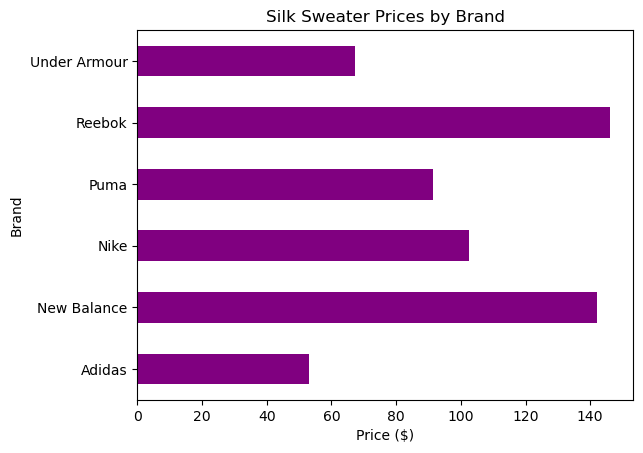

```python
# Compare Silk Sweaters
silk_sweaters = df[(df['Material'] == 'Silk') & (df['Category'] == 'Sweater')]
silk_sweaters.groupby('Brand')['Price'].mean().plot(kind='barh', color='purple', title='Silk Sweater Prices by Brand')
plt.xlabel('Price ($)')
plt.savefig("Silk Sweater Prices by Brand.png")
plt.show()
```

## 8. How do brands like Adidas and Puma compare in pricing for overlapping categories (e.g., Jackets)?

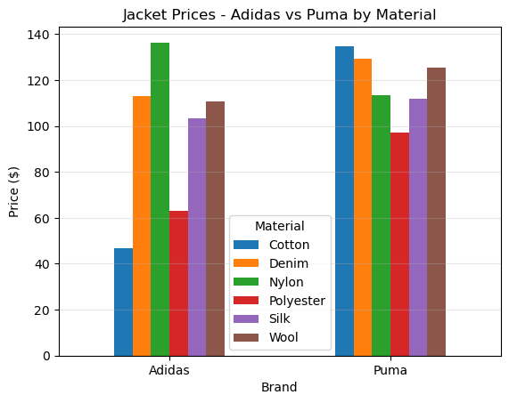

```python
# Create explicit figure first
plt.figure(figsize=(10, 6))

# Generate plot
adidas_puma.groupby(['Brand', 'Material'])['Price'].mean().unstack().plot(
    kind='bar',
    title='Jacket Prices - Adidas vs Puma by Material'
)

# Formatting
plt.ylabel('Price ($)')
plt.xticks(rotation=0)
plt.grid(axis='y', alpha=0.3)

# Save BEFORE showing, with safe filename
plt.savefig("Jacket_Prices_Adidas_vs_Puma_by_Material.png",
            dpi=300,
            bbox_inches='tight')

# Show after saving
plt.show()
```

## 9. What machine learning model yields the highest accuracy for price prediction using these features?

```
Model Performance:
Linear Regression: R² = 0.00
Random Forest: R² = -0.24
```

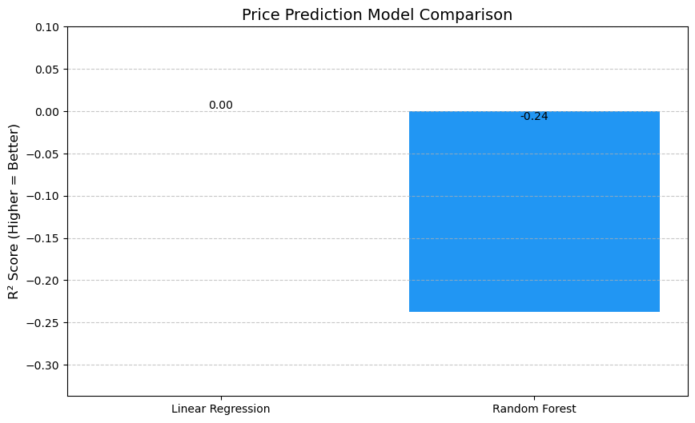

```python
# Step 1: Import Required Libraries
%matplotlib inline
import pandas as pd
import matplotlib.pyplot as plt
from sklearn.model_selection import train_test_split
from sklearn.linear_model import LinearRegression
from sklearn.ensemble import RandomForestRegressor
from sklearn.metrics import r2_score

# Step 2: Load Data
df = pd.read_csv(r"clothes images/clothes_price_prediction_data.csv")

# Step 3: Prepare Data (One-Hot Encoding)
X = pd.get_dummies(df[['Brand', 'Category', 'Material', 'Size']])
y = df['Price']

# Step 4: Split Data
X_train, X_test, y_train, y_test = train_test_split(
    X, y, test_size=0.2, random_state=42
)

# Step 5: Train Models
models = {
    "Linear Regression": LinearRegression(),
    "Random Forest": RandomForestRegressor(random_state=42)
}

scores = {}
for name, model in models.items():
    model.fit(X_train, y_train)
    y_pred = model.predict(X_test)
    scores[name] = r2_score(y_test, y_pred)

# Step 6: Display Results
print("Model Performance:")
for model, score in scores.items():
    print(f"{model}: R² = {score:.2f}")

# Step 7: Create Visualization (Fixed)
plt.figure(figsize=(10, 6))
bars = plt.bar(scores.keys(), scores.values(), color=['#4CAF50', '#2196F3'])

# Add value labels on bars
for bar in bars:
    yval = bar.get_height()
    plt.text(bar.get_x() + bar.get_width()/2,
             yval if yval > 0 else 0,  # Handle negative values
             f'{yval:.2f}',
             ha='center',
             va='bottom' if yval > 0 else 'top')

plt.title("Price Prediction Model Comparison", fontsize=14)
plt.ylabel("R² Score (Higher = Better)", fontsize=12)
plt.ylim(min(scores.values()) - 0.1, max(scores.values()) + 0.1)  # Dynamic scaling
plt.grid(axis='y', linestyle='--', alpha=0.7)

# Save and show
plt.savefig("model_comparison.png", dpi=300, bbox_inches='tight')
plt.show()
```

## 10. Which features (e.g., Brand, Material) are most predictive of price in a multivariate model?

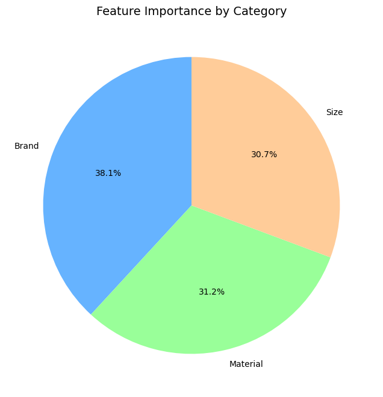

```python
# Step 1: Get feature importances from the Random Forest model
model = RandomForestRegressor(random_state=42)
model.fit(X_train, y_train)
importance = model.feature_importances_

# Step 2: Group by feature category (Brand, Material, etc.)
df_importance['Feature_Category'] = df_importance['Feature'].str.split('_').str[0]
grouped_importance = df_importance.groupby('Feature_Category')['Importance'].sum().sort_values(ascending=False)

# Step 3: Plot pie chart
plt.figure(figsize=(8, 8))
plt.pie(
    grouped_importance.values,
    labels=grouped_importance.index,
    autopct='%1.1f%%',
    startangle=90,
    colors=['#66b3ff', '#99ff99', '#ffcc99', '#ff9999']
)
plt.title('Feature Importance by Category', fontsize=14)
plt.savefig("feature importance by category.png")
plt.show()
```

## 11. Can clustering algorithms identify natural price segments based on attribute combinations?

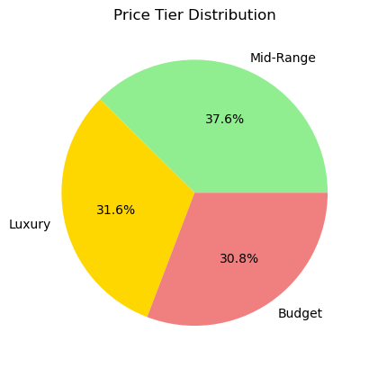

```python
from sklearn.cluster import KMeans

# Cluster prices into 3 groups
kmeans = KMeans(n_clusters=3)
df['Cluster'] = kmeans.fit_predict(df[['Price']])
cluster_labels = ['Budget', 'Mid-Range', 'Luxury']
df['Cluster'] = df['Cluster'].map({0: cluster_labels[0], 1: cluster_labels[1], 2: cluster_labels[2]})

df['Cluster'].value_counts().plot(kind='pie', autopct='%1.1f%%', colors=['lightgreen', 'gold', 'lightcoral'])
plt.title('Price Tier Distribution')
plt.ylabel('')
plt.savefig("Price Tier Distribution.png")
plt.show()
```

## 12. What attribute combinations (e.g., "Adidas Dress + Silk + Red") are most common in high-priced items?

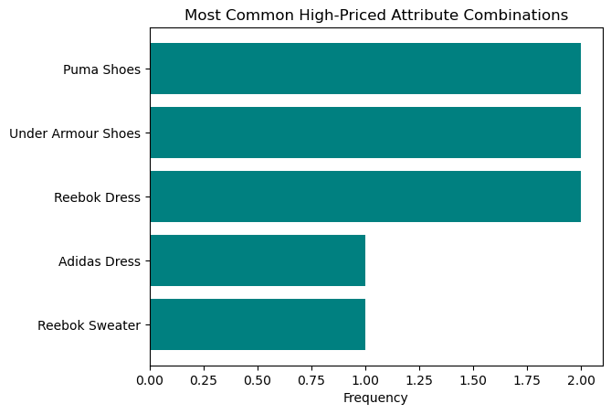

```python
# Filter top 5% priced items
high_price = df[df['Price'] > df['Price'].quantile(0.95)]
combinations = high_price.groupby(['Brand', 'Category', 'Material', 'Color']).size().reset_index(name='Count')

# Plot top 5 combinations
top_combinations = combinations.sort_values('Count', ascending=False).head(5)
plt.barh(top_combinations['Brand'] + " " + top_combinations['Category'], top_combinations['Count'], color='teal')
plt.title('Most Common High-Priced Attribute Combinations')
plt.xlabel('Frequency')
plt.gca().invert_yaxis()
plt.savefig("Most Common High-Priced Attribute Combinations.png")
plt.show()
```

## 13. Are there unexpected price outliers, and what attributes explain their deviation?

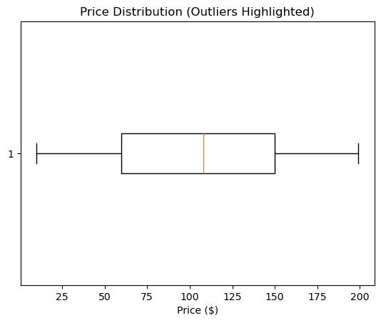

```python
plt.boxplot(df['Price'], vert=False)
plt.title('Price Distribution (Outliers Highlighted)')
plt.xlabel('Price ($)')
plt.savefig("Price Distribution (Outliers Highlighted).png")
plt.show()
```

## 14. Does the use of costlier materials (e.g., Silk) consistently justify higher prices across brands?

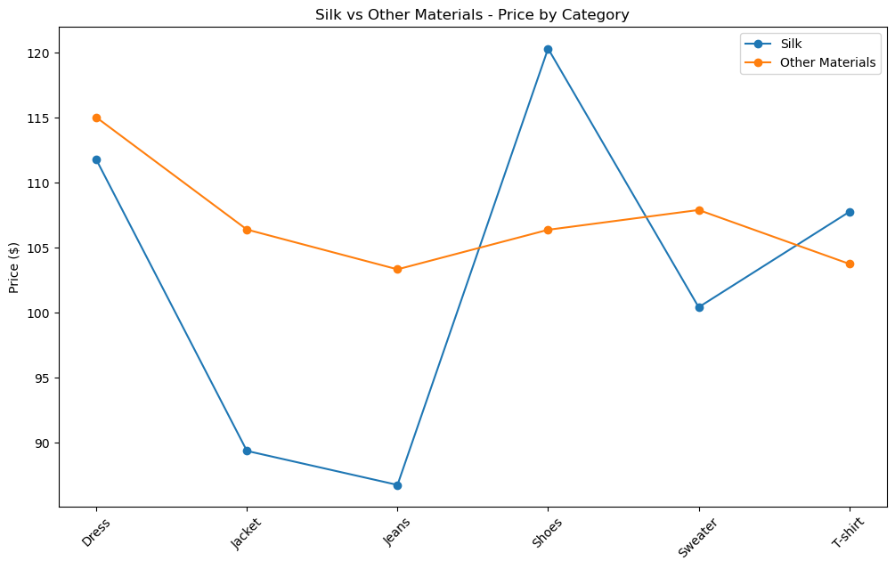

```python
import matplotlib.pyplot as plt

# Group data
silk_prices = df[df['Material'] == 'Silk'].groupby('Category')['Price'].mean()
other_prices = df[df['Material'] != 'Silk'].groupby('Category')['Price'].mean()

# Create plot with explicit figure
plt.figure(figsize=(12, 7))  # Set figure size

# Plot data
plt.plot(silk_prices.index, silk_prices.values, marker='o', label='Silk')
plt.plot(other_prices.index, other_prices.values, marker='o', label='Other Materials')

# Formatting
plt.title('Silk vs Other Materials - Price by Category')
plt.ylabel('Price ($)')
plt.xticks(rotation=45)
plt.legend()

# Save with safe filename and bbox adjustment
plt.savefig("Silk_vs_Other_Materials_Price_by_Category.png", dpi=300, bbox_inches='tight')
plt.show()
```

## 15. How could dynamic pricing strategies optimize revenue for size-color combinations with low demand?

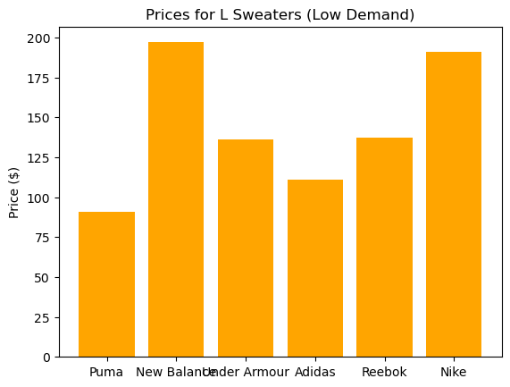

```python
# Identify low-demand SKUs (e.g., low frequency)
low_demand = df['Size'].value_counts().idxmin()
sku_data = df[(df['Size'] == low_demand) & (df['Category'] == 'Sweater')]

plt.bar(sku_data['Brand'], sku_data['Price'], color='orange')
plt.title(f'Prices for {low_demand} Sweaters (Low Demand)')
plt.ylabel('Price ($)')
plt.savefig("Prices for {low_demand} Sweaters.png")
plt.show()
```